# Identifying Optimal Environments for Aquaculture

R

MEDS

data-viz

Geospatial

Author

Joshua Ferrer-Lozano

Published

November 28, 2025

# Introduction

As global demand for seafood continues to rise, pressure on wild fisheries has intensified. Marine aquaculture offers a sustainable alternative, reducing reliance on wild stocks while supporting economic growth. Research suggests that the availability of suitable ocean space will not constrain aquaculture expansion (Gentry et al., 2017), creating opportunities for countries like the United States to develop systems that balance economic and environmental objectives.

This project evaluates the suitability of U.S. West Coast Exclusive Economic Zones (EEZs) for oyster aquaculture by examining two key environmental factors: sea surface temperature (SST) and bathymetry. Using satellite‑derived SST data (2008–2012) and regional bathymetry, we quantify areas that meet oyster‑specific thresholds. By integrating spatial data with habitat requirements, this study identifies where conditions are most favorable for expanding sustainable oyster aquaculture along the West Coast.

# Research Question

Where along the U.S. West Coast are environmental conditions most suitable for oyster aquaculture?

# Background

Aquaculture is increasingly recognized as a critical component of global food security and coastal economies, yet identifying where species can thrive requires careful integration of environmental data. In this blog post, we will identify where along the U.S. West Coast are environmental conditions most suitable for oyster aquaculture. Using sea surface temperature (SST) data, bathymetry rasters, and Exclusive Economic Zone (EEZ) boundaries, we identify areas most favorable for oyster cultivation. By combining geospatial modeling with cartographic visualization, we highlight how environmental data science can inform sustainable aquaculture planning.

# Highlights of the Analysis

- **Raster Reclassification**: Converted SST and depth rasters into binary suitability maps based on oyster thresholds.
- **Map Algebra**: Combined multiple criteria (temperature × depth) to produce a composite suitability raster.
- **Zonal Statistics**: Summed suitable areas within EEZ boundaries to quantify aquaculture potential by region.
- **Cartographic Visualization**: Produced clear maps with legends, units, and orientation cues to communicate results effectively.
- Used geospatial tools including **R**, the `terra` and `stars` package.

These steps illustrate how spatial data science integrates multiple datasets to answer applied environmental questions.

# Dataset Descriptions

- **Sea Surface Temperature (2008–2012)**: NOAA Coral Reef Watch 5‑km SST data, averaged across five years and converted from Kelvin to Celsius.
- **Bathymetry**: GEBCO gridded bathymetry dataset, reprojected and resampled to align with SST rasters.
- **Exclusive Economic Zones (EEZs)**: Marine Regions shapefiles defining U.S. West Coast EEZ boundaries.
- **Species Requirements**: Oyster depth and temperature preferences from SeaLifeBase.

# Methods

The workflow begins with preprocessing SST and bathymetry data, followed by reclassification into suitability ranges, combining criteria with map algebra, and aggregating results by EEZ.

This geospatial analysis utilized key concepts such as: - Combining raster and vector data - Resampling raster data - Map algebra - Zonal statistics

# Analysis 1: Mean Sea Surface Temperature

## Step 1: Load Libraries and Import Data

We begin by loading libraries and importing EEZ boundaries, bathymetry, and SST rasters.

```r
# Load libraries for geospatial and data analysis
suppressPackageStartupMessages({
library(tidyverse)   # Data wrangling and plotting
library(stars)       # Raster handling
library(terra)       # Raster operations
library(sf)          # For vector data
library(tmap)        # For visualization
library(knitr)       # Table formatting
library(kableExtra)  # Table formatting
})
```

```r
# Read in Exclusive Economic Zone (EEZ) shapefile
regions_clean <- st_read("data/wc_regions_clean.shp")
# Read in depth raster
depth <- rast("data/depth.tif")

# Read in Sea Surface Temperature rasters
sst_2008 <- rast("data/average_annual_sst_2008.tif")
sst_2009 <- rast("data/average_annual_sst_2009.tif")
sst_2010 <- rast("data/average_annual_sst_2010.tif")
sst_2011 <- rast("data/average_annual_sst_2011.tif")
sst_2012 <- rast("data/average_annual_sst_2012.tif")
```

## Step 2: Process the Data

We assume WGS84 (EPSG:4326) as the common CRS, verify CRS, stack the five rasters (2008 - 2012), calculate the mean and convert Kelvin to Celsius

```r
# Stack SST rasters into multi-layer Spatraster
sst_stack <- c(sst_2008, sst_2009, sst_2010, sst_2011, sst_2012)

# Compute the mean of SST across years
sst_mean <- mean(sst_stack)

# Convert Kelvin to Celsius
sst_celsius <- sst_mean - 273.15

# Replace NA values with 0
sst_celsius[is.na(sst_celsius)] <- 0

# Add warning if the range is wrong
if (max(values(sst_celsius), na.rm=TRUE) > 40) warning("SST unusually high — check conversion.")
```

Plot Mean Surface Temperature on West Coast

```
[tm_raster()] Arguments `fill.scale` and `fill.legend` unknown.
[plot mode] fit legend/component: Some legend items or map compoments do not
fit well, and are therefore rescaled.
ℹ Set the tmap option `component.autoscale = FALSE` to disable rescaling.
```

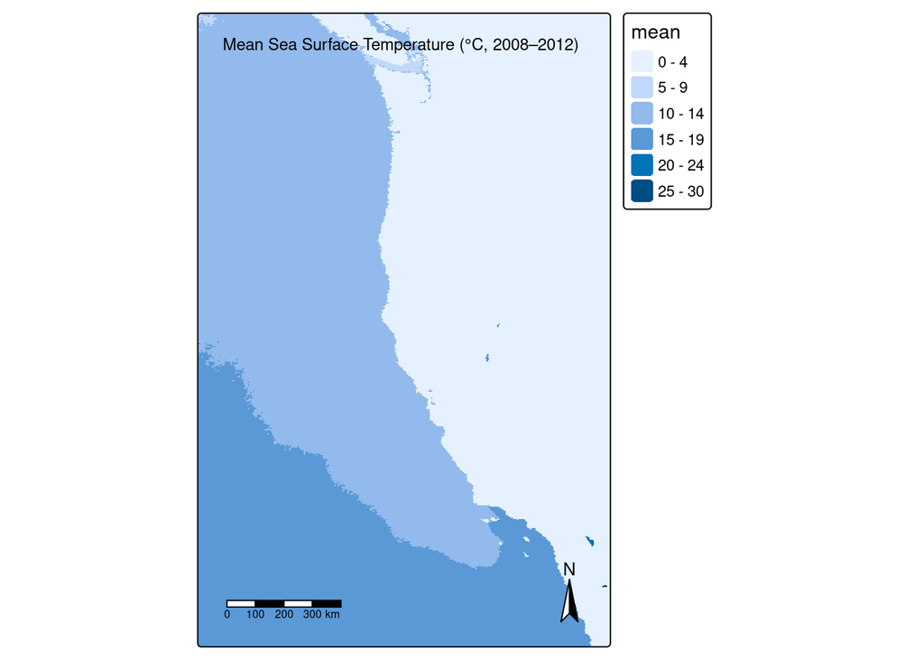

```r
# Convert SST raster to stars object for a more robust plot
sst_stars <- st_as_stars(sst_celsius)

tm_shape(sst_stars) +
  tm_raster(fill.scale = tm_scale(values = "viridis"),
            fill.legend = tm_legend(title = "Temperature (C)")) +
  tm_title("Mean Sea Surface Temperature (°C, 2008–2012)", position = c("center", "top")) +
  tm_scalebar(position = c("left", "bottom")) +
  tm_compass(position = c("right", "bottom"))
```

Figure 1: The mean sea surface temperature (SST) raster from the years 2008 - 2012 provides insight into the temperature variation along the west coast of the united states from California to Washington state with warmer waters on average in the southern regions and cooler in the northern regions.

## Step 3: Reproject, crop and resample bathymetry to SST resolution

```r
# Align depth raster to the SST raster

# Reproject CRS
depth_proj <- project(depth, crs(sst_celsius))
# Crop to SST extent
depth_crop <- crop(depth_proj, sst_celsius)
# Resample resolution
depth_resample <- resample(depth_crop, sst_celsius, method = "near")
```

Re-sampling with the nearest neighbor preserves categorical depth bins.

## Step 4: Verify Alignments

```r
# Verify alignments of CRS, resolution and extent
crs(sst_celsius) == crs(depth_resample)
```

```
[1] TRUE
```

```r
if (!identical(res(sst_celsius), res(depth_resample))) stop("Resolution mismatch.")
```

Verify CRS, resolution and extent match.

## Step 5: Identify Suitable Environments for Oysters

Next, we identify suitable oyster environments by reclassifying SST and depth rasters into binary maps.

According to research, favorable environments for oysters include: - Sea surface temperature (SST) range: 11 - 30 degrees Celsius - Depth Range: 0 - 70 meters

We reclassify SST and depth rasters into binary suitability maps and combine them.

```r
# Create matrix to reclassify SST suitability for oysters based on 11–30 C
sst_suit <- classify(sst_celsius,
                     rbind(c(-Inf, 11, 0), # Unsuitable temp below 11 C
                           c(11, 30, 1),   # Suitable temp at 11 - 30 C
                           c(30, Inf, 0))) # Unsuitable temp above 30 C

# Create matrix to reclassify depth suitability for oysters based on 0–70 m
depth_suit <- classify(depth_resample,
                       rbind(c(-Inf, -70, 0),  # Unsuitable elevation above sea level
                             c(-70, 0, 1),     # Suitable between -70 - 0 m sea level
                             c(0, Inf, 0)))    # Unsuitable elevation above sea level

# Test to verify our matrix of binary output
testthat::expect_true(all(unique(values(sst_suit)) %in% c(0,1)))


# Combine suitability (map algebra: both must be 1)
suitability <- sst_suit * depth_suit
```

We assume depths are negative, so suitable oyster depths are −70 to 0 m. If positive, thresholds would be 0–70.

## Step 6: Convert Raster to Dataframe and Plot

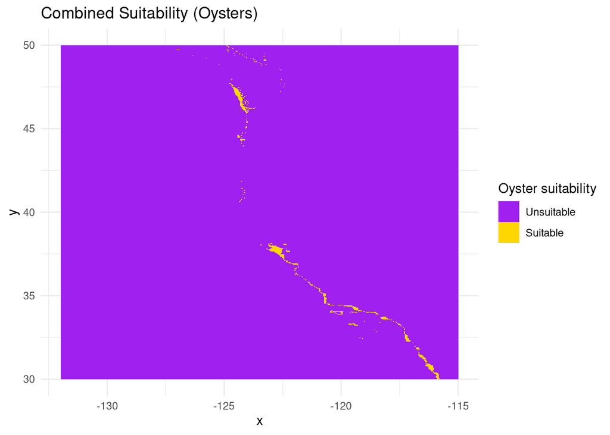

```r
# Convert raster to dataframe
suit_df <- as.data.frame(suitability, xy = TRUE, na.rm = TRUE)

# Plot with ggplot
ggplot(suit_df) +
  geom_raster(aes(x = x, y = y, fill = factor(mean))) +
  scale_fill_manual(values = c("0" = "purple", "1" = "gold"),
                    name = "Oyster suitability",
                    labels = c("Unsuitable", "Suitable")) +
  labs(title = "Combined Suitability (Oysters)") +
  theme_minimal()
```

Figure 2: Combined suitability raster. Gold areas represent suitable oyster environments, purple areas unsuitable.”

## Step 7: Suitability by EEZ

We aggregate suitable habitat by EEZ using zonal statistics, which sum the total suitable area (km^2) within each EEZ boundary.

```r
# Convert EEZ polygons to terra vector
eez_v <- vect(regions_clean)
# Align CRS
eez_v <- project(eez_v, crs(sst_celsius))

# Rasterize EEZ IDs to each polygon
eez_v$eez_id <- seq_len(nrow(eez_v))
eez_r <- rasterize(eez_v, sst_celsius, field = "eez_id")

# Calculate cell area in km^2
cell_area <- cellSize(sst_celsius, unit = "km")

# Multiply suitable area raster by cell to get suitable area per cell
area_suitable <- suitability * cell_area

# Zonal sum of suitable area per EEZ
area_by_eez <- zonal(area_suitable, eez_r, fun = "sum", na.rm = TRUE)

# Convert to data frame and rename columns correctly
area_by_eez <- as.data.frame(area_by_eez) |>
  dplyr::rename(suitable_km2 = mean)

# Join zonal statistics to EEZ polygons
eez_sf_out <- st_as_sf(eez_v) |>
  left_join(area_by_eez, by = "eez_id")
```

Convert EEZ polygons to vector, aligned the CRS, rasterized EEZ IDs, applied map algebra, converted to data frame. Summing suitable cell areas by EEZ allows us to rank zones by aquaculture potential. Lastly, I joined zonal statistics to EEZ polygons.